# Risk-Reward Plots

Tark Auf

2020-10-17

# 1 Returns of financial stocks

```r
#loading the data
nyse <- read_csv(here::here("data","nyse.csv"))

glimpse(nyse)
```

```
## Rows: 508
## Columns: 6
## $ symbol        <chr> "MMM", "ABB", "ABT", "ABBV", "ACN", "AAP", "AFL", "A", …
## $ name          <chr> "3M Company", "ABB Ltd", "Abbott Laboratories", "AbbVie…
## $ ipo_year      <chr> "n/a", "n/a", "n/a", "2012", "2001", "n/a", "n/a", "199…
## $ sector        <chr> "Health Care", "Consumer Durables", "Health Care", "Hea…
## $ industry      <chr> "Medical/Dental Instruments", "Electrical Products", "M…
## $ summary_quote <chr> "https://www.nasdaq.com/symbol/mmm", "https://www.nasda…
```

Based on this dataset, create a table and a bar plot that shows the number of companies per sector, in descending order

```r
companies_per_sector <- nyse %>%
                        dplyr::group_by(sector) %>%
                        dplyr::count(sort = TRUE) %>%
                        select(sector, number = n)
companies_per_sector
```

```
## # A tibble: 12 x 2
## # Groups:   sector [12]
##    sector                number
##    <chr>                  <int>
##  1 Finance                   97
##  2 Consumer Services         79
##  3 Public Utilities          60
##  4 Capital Goods             45
##  5 Health Care               45
##  6 Energy                    42
##  7 Technology                40
##  8 Basic Industries          39
##  9 Consumer Non-Durables     31
## 10 Miscellaneous             12
## 11 Transportation            10
## 12 Consumer Durables          8
```

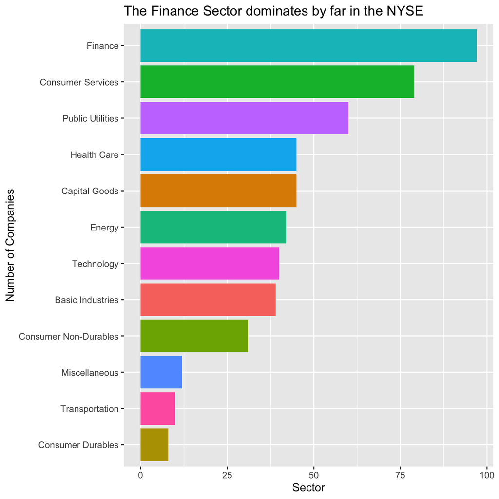

```r
comp_per_sector_plot <- ggplot(companies_per_sector,
                               aes(y = reorder(sector, number),
                                   x = number,
                                   fill = factor(sector)))+
                        geom_bar(stat = "identity")+
                        theme(axis.text.x=element_text(angle=0),
                              legend.position = 'none') +
                        labs(x = "Sector",
                             y = "Number of Companies",
                             title = "The Finance Sector dominates by far in the NYSE")

comp_per_sector_plot
```

Next, let’s choose the [Dow Jones Industrial Aveareg (DJIA)](https://en.wikipedia.org/wiki/Dow_Jones_Industrial_Average) stocks and their ticker symbols and download some data. Besides the thirty stocks that make up the DJIA, we will also add `SPY` which is an SP500 ETF (Exchange Traded Fund).

```r
djia_url <- "https://en.wikipedia.org/wiki/Dow_Jones_Industrial_Average"

#get tables that exist on URL
tables <- djia_url %>%
          read_html() %>%
          html_nodes(css="table")

# parse HTML tables into a dataframe called djia.
# Use purr::map() to create a list of all tables in URL
djia <- map(tables, . %>%
            html_table(fill=TRUE)%>%
            clean_names())


# constituents
table1 <- djia[[2]] %>% # the second table on the page contains the ticker symbols
          mutate(date_added = ymd(date_added),

         # if a stock is listed on NYSE, its symbol is, e.g., NYSE: MMM
         # We will get prices from yahoo finance which requires just the ticker

         # if symbol contains "NYSE*", the * being a wildcard
         # then we just drop the first 6 characters in that string
         ticker = ifelse(str_detect(symbol, "NYSE*"),
                         str_sub(symbol,7,11),
                         symbol))

# we need a vector of strings with just the 30 tickers + SPY
tickers <- table1 %>%
           select(ticker) %>%
           pull() %>% # pull() gets them as a sting of characters
           c("SPY") # and lets us add SPY, the SP500 ETF
```